# MIDI-MT - Module for interaction with “Joysticks/Gamepads”

MIDI-MT Documentation in English

## Control using Joystick and Gamepad

- Settings for the interaction module with “Joysticks” and “Gamepads”
  - Control mode
  - Restrictions
- Control Binding Settings
- Configuration file

Allows you to use standard “**Joysticks**” and “**Gamepads**” in two modes, as an input keyboard or as a remote control. The module translates commands from a gamepad or joystick into the MIDI protocol. In “**input device**” mode, direction controls are used as sliders, and buttons are used for their intended purpose.

### Settings for the interaction module with “Joysticks” and “Gamepads”

- The “**Available devices**” list shows currently connected devices.
- Selecting “**Change step**” sets the adjustment scale, available values from `1` to `42`. The maximum scale value `127`.
- Selecting “**Device polling period**” specifies the amount of time in milliseconds between polling connected devices. The default value is 50 milliseconds.
- The “**Input mode**”/“**Control mode**” switch sets the executable functions of the devices. In input mode, the devices work as an external MIDI keyboard, in control mode - as a remote control for the “**Audio Mixer**”, “**Smart Home**” and “**Light Control**” groups.
- The “**Scene**” field allows you to specify the MIDI scene number in case of conflict with other connected MIDI devices. The default value `101`.
- The option “**Use directions as buttons**” works in input device mode and allows you to use each directional (plane) control as 4 independent buttons.
- The “**Horizontal Directions in JOG Mode**” option forces the horizontal direction to be used in `not end` mode. Convenient to use in Adobe Prmiere Pro to move along the timeline.
- Selecting “**Control Mode Settings**” allows you to limit the controlled groups to one or more from the list of “**Audio Mixer**”, “**Smart Home**” and “**Light Control**” groups.

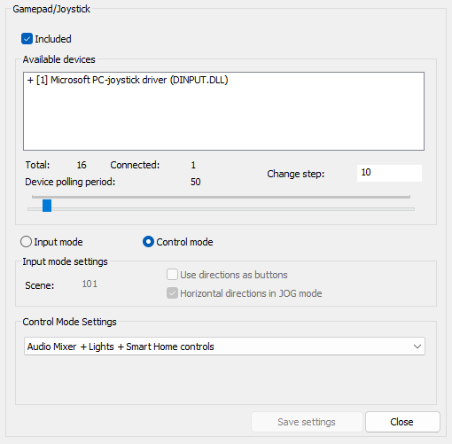

Using the Gamepad or Joystick you can control all the ‘**Slider**’, ‘**Fader**’ or ‘**Jog**’ controls configured in the `MIDI-MT` configuration. In control mode, adjustment is possible in the “**Audio Mixer**”, “**Smart Home**” and “**Light Control**” groups; all connected devices duplicate each other’s functions.

###### Control mode:

1. Operating logic in control mode:

With horizontal directions you select control, and with vertical directions you adjust the level. Changing adjustable groups is done using buttons `1` and `2` on the device. Button `3` is responsible for enabling/disabling the selected control. Button `4` sets the average level for the selected control, or returns its previous value. All buttons except `1` and `2` have trigger behavior. Buttons `1` and `2` operate in the “scrolling” mode. In control mode, all connected devices duplicate each other.

1. Key combinations in control mode:
- buttons `1`, `2`: scrolling through groups, in accordance with the selection of “Control mode settings”.
- `horizontal direction`: scrolling through controls in a group (right/left).
- `vertical direction`: increase or decrease values (up/down), according to the “Change step” selection
- button `3`: temporarily set the value to `0`, without making changes to the database.
- button `4`: temporarily setting the value to `50%`, without making changes to the database.
- for buttons `3`, `4`, pressing again restores the original value.

###### Restrictions:

Due to operating system limitations, only two devices can be used simultaneously. At the same time, the system supports physical connection of up to `16` devices.

### Control Binding Settings

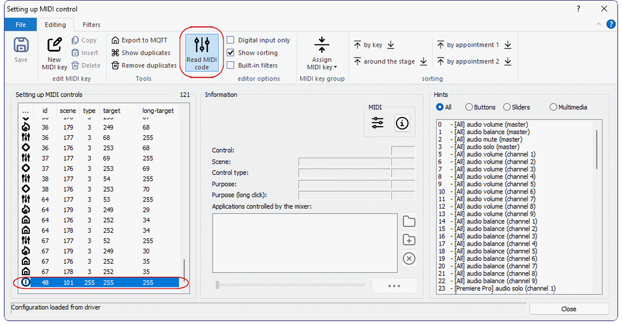

You can configure the payload of controllers in “**Input Mode**” in the editor. To determine the device control numbers, use the “**Read MIDI code**” button. Each of the connected controllers has unique control numbers. There are no restrictions on linking functions to device controls.

#### Configuration file

It is also possible to edit the configuration file in any editor you are familiar with. The main section of the settings for the interaction module with “Joysticks” and “Gamepads” looks like this:

```yaml
    ...
    },
    "gamepad": {
        "enable": true,
        "rcontrols": true,
        "directasbutton": false,
        "horizontalmode": true,
        "scene": 101,
        "step": 10,
        "polling": 50,
        "type": 6
    },
    "units":[ ...
    ... ]
```